# Instructions on submitting Project #1 Report

Nathan Taback

2018-10-28

# Submission Instructions for Project #1 Report

Your report and any other documents should be submitted on Quercus [here](https://q.utoronto.ca/courses/62302/assignments/83181).

## Submit your Report

1. The report for project #1 should follow the guidelines outlined here.
2. The report should be an html, pdf, or .docx document generated from either an RMarkdown file or Jupyter notebook (NB: currently Jupyter notebooks don’t have a straight forward way to export a notebook to MS Word format).

## Submit Data and other Documents used in your Report

3. The instructor should be able to easily reproduce your report (i.e., run your Jupyter notebook or Knit your RMarkdown document).
4. In order to reproduce your report the instructor will need the data you used and any accompanying files (e.g., a picture stored as a .jpg file).
5. Store the data that you used in your report in the cloud (e.g., Github, Dropbox, Google Drive, etc.). Then you should be able to read in the data by specifying the url of the file.

For example, the file `sta2453grading.csv` is stored in the Github repository https://github.com/ntaback/STA2453. The url for `sta2453grading.csv` is https://raw.githubusercontent.com/ntaback/STA2453/master/sta2453grading.csv

In both examples below files starting with https:// will automatically be downloaded.

### Example using R

```r
library(tidyverse)
mydata <- read_csv(file = "https://raw.githubusercontent.com/ntaback/STA2453/master/sta2453grading.csv")
mydata
```

```
## # A tibble: 13 x 3
##    Project       Item                  Value
##    <chr>         <chr>                 <chr>
##  1 Project #1    Proposal              5%
##  2 <NA>          Draft report          5%
##  3 <NA>          Final report          10%
##  4 <NA>          Presentation          20%
##  5 Project #2    Proposal              5%
##  6 <NA>          Draft report          5%
##  7 <NA>          Final report          10%
##  8 <NA>          Presentation          20%
##  9 Participation Attendance            5%
## 10 <NA>          Active in discussions 5%
## 11 <NA>          Prepare for class     5%
## 12 <NA>          In-class assignments  5%
## 13 <NA>          <NA>                  <NA>
```

### Example using Python.

```python
import pandas as pd
mydata = pd.read_csv('https://raw.githubusercontent.com/ntaback/STA2453/master/sta2453grading.csv')
print(mydata)
```

```
##           Project                   Item Value
## 0      Project #1               Proposal    5%
## 1             NaN           Draft report    5%
## 2             NaN           Final report   10%
## 3             NaN           Presentation   20%
## 4      Project #2               Proposal    5%
## 5             NaN           Draft report    5%
## 6             NaN           Final report   10%
## 7             NaN           Presentation   20%
## 8   Participation             Attendance    5%
## 9             NaN  Active in discussions    5%
## 10            NaN      Prepare for class    5%
## 11            NaN   In-class assignments    5%
## 12            NaN                    NaN   NaN
```

#### Convert Jupyter Notebook into a Report without Code Cells

To convert a Jupyter Notebook to html, pdf, or LaTeX consider using [nbconvert](https://nbconvert.readthedocs.io/en/latest/install.html). For example, to convert movies.ipynb to an html document **without code cells** the command line syntax for nbconvert is:

`jupyter nbconvert --TemplateExporter.exclude_input=True movies.ipynb`

### Pictures

The syntax for incorporating an image into either an RMarkdown or Jupyter notebook is `![](kitten.jpg)`

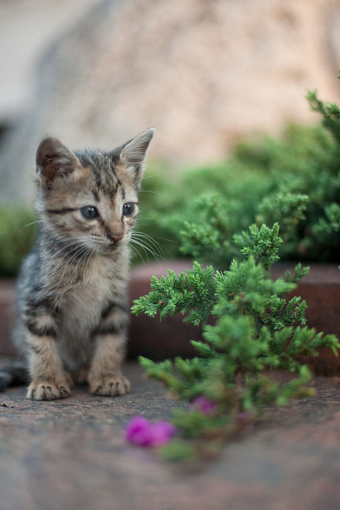